# Course 2 - Assigment 2

## Run an analysis of variance.

Instructionsless

Run a Chi-Square Test of Independence.

You will need to analyze and interpret post hoc paired comparisons in instances where your original statistical test was significant, and you were examining more than two groups (i.e. more than two levels of a categorical, explanatory variable).

Note: although it is possible to run large Chi-Square tables (e.g. 5 x 5, 4 x 6, etc.), the test is really only interpretable when your response variable has only 2 levels (see Graphing decisions flow chart in Bivariate Graphing chapter).

```python
%matplotlib inline
import pandas as pd
import numpy as np
import matplotlib.pyplot as plt
import seaborn as sns
import warnings
import scipy.stats
warnings.filterwarnings('ignore')
```

```
:0: FutureWarning: IPython widgets are experimental and may change in the future.
```

```python
data = pd.read_csv("../e.csv", low_memory=False)
```

# Codes

## S2AQ5B - How often drank beer last 12 months

- 1: Every day
- 2: Nearly every day
- 3: 3 to 4 times a week
- 4: 2 times a week
- 5: Once a week
- 6: 2 to 3 times a month
- 7: Once a month
- 8: 7 to 11 times in the last year
- 9: 3 to 6 times in the last year
- 10: 1 or 2 times in the last year
- 99: Unknown
- BL: NA, did not drink or unknown if drank beer in last 12 months

## S2BQ2E - Number of episodes of alcohol dependence

- 1-98: Number of episodes
- 99: Unknown
- BL: NA, lifetime abstainer; did not meet symptom and/or duration criteria for lifetime alcohol dependence

## S2DQ1 - Blood/natural Father ever an alcoholic or problem drinker

- 1: Yes
- 2: No
- 9: Unknown

## S2DQ2 - Blood/natural Mother ever an alcoholic or problem drinker

- 1: Yes
- 2: No
- 9: Unknown

## S2AQ5D - Number of beers usually consumed on days when drank beer in last 12 months

- 1-42: Number of beers
- 99: Unknown
- BL: NA

## What we'll do?

Our explanatory variable will be dependent parent. The responsible variable will be drink frequency, that we'll categorize into two groups. Then, we'll do a chi-2 test and its post hoc (even if it ins't necessary).

```
Number of NAs in S2AQ5B 0
Number of NAs in S2DQ1  0
Number of NAs in S2DQ2  0
Count list for our new variable Alcohol Profile last 12 monts!
1     7170
2    10060
dtype: int64
```

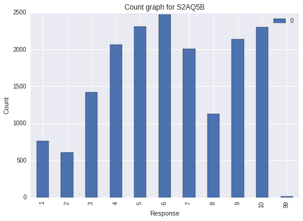

```
Count list for Dependent Parent:
0    12941
1     3849
2      440
dtype: int64
alcohol_profile_12m     1     2
dependent_parent
0                    5386  7555
1                    1595  2254
2                     189   251
alcohol_profile_12m         1         2
dependent_parent
0                    0.751185  0.750994
1                    0.222455  0.224056
2                    0.026360  0.024950
chi-square value, p value, expected counts
(0.37393684511592784, 0.82946992851044987, 2, array([[ 5385.198491  ,  7555.801509  ],
       [ 1601.70226349,  2247.29773651],
       [  183.0992455 ,   256.9007545 ]]))
Just one post hoc, we shouldn't do it, because H0 wasn't reject, but just to see the results:
The new p-value for significance would be 0.05/3
alcohol_profile_12m     1     2
COMP1v2
0                    5386  7555
1                    1595  2254
alcohol_profile_12m         1         2
COMP1v2
0                    0.771523  0.770211
1                    0.228477  0.229789
chi-square value, p value, expected counts
(0.032636038918592958, 0.8566387953234923, 1, array([[ 5380.65044669,  7560.34955331],
       [ 1600.34955331,  2248.65044669]]))
```

```python
#We don't have NA data
print "Number of NAs in S2AQ5B",
print len(data["S2AQ5D"][data["S2AQ5B"].isnull()])
print "Number of NAs in S2DQ1 ",
print len(data["S2AQ5B"][data["S2DQ1"].isnull()])
print "Number of NAs in S2DQ2 ",
print len(data["S2AQ5B"][data["S2DQ2"].isnull()])

#Discarding the 99 and BL cases
#The BL is displayed as " "
#And unknown cases

sub_data = data[:][(data["S2AQ5D"] != "99") & (data["S2AQ5D"] != " ")]
sub_data = sub_data[:][sub_data["S2DQ1"] != 9]
sub_data = sub_data[:][sub_data["S2DQ2"] != 9]
#sub_data = sub_data[:][(sub_data["S2AQ5B"] != 99 & sub_data["S2AQ5B"] != " ")]
sub_data["S2AQ5B"] = sub_data["S2AQ5B"].convert_objects(convert_numeric=True)


sub_data["alcohol_profile_12m"] = sub_data["S2AQ5B"].apply(lambda x : 1 if int(x) < 6 else 2)
print "Count list for our new variable Alcohol Profile last 12 monts!"
print sub_data["alcohol_profile_12m"].value_counts(sort=False)

bar = pd.DataFrame(sub_data["S2AQ5B"].convert_objects(convert_numeric=True).value_counts())
bar = bar.sort()
ax = bar.plot(kind='bar')
plt.ylabel("Count")
plt.xlabel("Response")
plt.title('Count graph for S2AQ5B')
plt.show()

#Create new variable
sub_data["dependent_parent"] = sub_data.apply(lambda x: 1 if x["S2DQ1"]==1 else 2 if x["S2DQ2"]==1 else 0 , axis = 1)
print "Count list for Dependent Parent: "
print sub_data["dependent_parent"].value_counts(sort=False)


# contingency table of observed counts
ct1=pd.crosstab(sub_data['dependent_parent'], sub_data['alcohol_profile_12m'])
print (ct1)

# column percentages
colsum=ct1.sum(axis=0)
colpct=ct1/colsum
print(colpct)

# chi-square
print ('chi-square value, p value, expected counts')
cs1= scipy.stats.chi2_contingency(ct1)
print (cs1)

#Post Hoc
print "Just one post hoc, we shouldn't do it, because H0 wasn't reject, but just to see the results:"
print "The new p-value for significance would be 0.05/3"
recode2 = {0: 0, 1: 1}
sub_data['COMP1v2']= sub_data['dependent_parent'].map(recode2)

# contingency table of observed counts
ct1=pd.crosstab(sub_data['COMP1v2'], sub_data['alcohol_profile_12m'])
print (ct1)

# column percentages
colsum=ct1.sum(axis=0)
colpct=ct1/colsum
print(colpct)

# chi-square
print ('chi-square value, p value, expected counts')
cs1= scipy.stats.chi2_contingency(ct1)
print (cs1)
```

# Conclusion

The Chi2 showed that there's no dependence between the drinking frequency and having a dependent parent. The p-value is very high, so we don't reject the null hypothesis.